# workbook-mjg

Put your own name here

2022-10-24

# 1 R Markdown

## 1.1 Tutorial workbook

This workbook contains the code from the tutorial paper: *Data visualisation using R, for researchers who don’t use R*

You can add notes to this file and/or make a duplicate copy to work with your own dataset.

The document outline tool will help you navigate this workbook more easily (Ctrl+Shift+O on Windows, Cmd+Shift+O on Mac).

This workbook contains code chunks for all the the code and activities in the tutorial. If you wish to create extra code chunks, you can use the Insert Code - R menu (a green box with a C and a plus sign) or use the keyboard shortcuts (Ctrl+Alt+I on Windows, Cmd+Option+I on Mac).

When you are working in a Markdown document, the working directory (where R looks for data files to import, and where it will save any output you create) will default to the folder that the .Rmd file is stored in when you open RStudio by opening the Markdown document. For this reason, make sure that the .Rmd file and the data file are in the same folder before you begin.

# 2 Chapter 2: Getting Started

## 2.1 Loading packages

Remember that you need to install the packages before you can load them - but never save the install code in your Markdown.

```r
library("magrittr")
library("ggplot2")
library("readr")
library("dplyr")
library("tidyr")
library("patchwork")
library("pander")
```

## 2.2 Loading data

```r
dat <- read_csv(file = "ldt_data.csv")
```

## 2.3 Handling numeric factors

```r
summary(dat)
```

```
      id                 age           language       rt_word
 Length:100         Min.   :18.00   Min.   :1.00   Min.   :256.3
 Class :character   1st Qu.:24.00   1st Qu.:1.00   1st Qu.:322.6
 Mode  :character   Median :28.50   Median :1.00   Median :353.8
                    Mean   :29.75   Mean   :1.45   Mean   :353.6
                    3rd Qu.:33.25   3rd Qu.:2.00   3rd Qu.:379.5
                    Max.   :58.00   Max.   :2.00   Max.   :479.6
   rt_nonword       acc_word       acc_nonword
 Min.   :327.3   Min.   : 89.00   Min.   :76.00
 1st Qu.:438.8   1st Qu.: 94.00   1st Qu.:82.75
 Median :510.6   Median : 95.00   Median :85.00
 Mean   :515.8   Mean   : 95.01   Mean   :84.90
 3rd Qu.:582.9   3rd Qu.: 96.25   3rd Qu.:88.00
 Max.   :706.2   Max.   :100.00   Max.   :93.00
```

```r
str(dat)
```

```
spc_tbl_ [100 × 7] (S3: spec_tbl_df/tbl_df/tbl/data.frame)
 $ id         : chr [1:100] "S001" "S002" "S003" "S004" ...
 $ age        : num [1:100] 22 33 23 28 26 29 20 30 26 22 ...
 $ language   : num [1:100] 1 1 1 1 1 1 1 1 1 1 ...
 $ rt_word    : num [1:100] 379 312 405 298 316 ...
 $ rt_nonword : num [1:100] 517 435 459 336 401 ...
 $ acc_word   : num [1:100] 99 94 96 92 91 96 95 91 94 94 ...
 $ acc_nonword: num [1:100] 90 82 87 76 83 78 86 80 86 88 ...
 - attr(*, "spec")=
  .. cols(
  ..   id = col_character(),
  ..   age = col_double(),
  ..   language = col_double(),
  ..   rt_word = col_double(),
  ..   rt_nonword = col_double(),
  ..   acc_word = col_double(),
  ..   acc_nonword = col_double()
  .. )
 - attr(*, "problems")=<externalptr>
```

```r
dat <- mutate(dat, language = factor(
    x = language, # column to translate
    levels = c(1, 2), # values of the original data in preferred order
    labels = c("monolingual", "bilingual") # labels for display
  ))
```

## 2.4 Argument names

The above code could also be written as:

```r
dat <- mutate(dat, language = factor(
  language,
  c(1, 2),
  c("monolingual", "bilingual")
))
```

Load `dat.rda` for safety.

```r
load("dat.rda")
```

## 2.5 Summarising data

```r
dat %>%
  group_by(language) %>%
  count() %>%
  ungroup()
```

| language | n |
| --- | --- |
| Monolingual | 55 |
| Bilingual | 45 |

```r
dat %>%
  count()
```

| n |
| --- |
| 100 |

```r
dat %>%
  summarise(mean_age = mean(age),
            sd_age = sd(age),
            n_values = n())
```

| mean_age | sd_age | n_values |
| --- | --- | --- |
| 29.75 | 8.285 | 100 |

```r
age_stats <- dat %>%
  summarise(mean_age = mean(age),
            sd_age = sd(age),
            n_values = n())
```

```r
dat %>%
  group_by(language) %>%
  summarise(mean_age = mean(age),
            sd_age = sd(age),
            n_values = n()) %>%
  ungroup()
```

| language | mean_age | sd_age | n_values |
| --- | --- | --- | --- |
| Monolingual | 27.96 | 6.782 | 55 |
| Bilingual | 31.93 | 9.44 | 45 |

## 2.6 Bar chart of counts

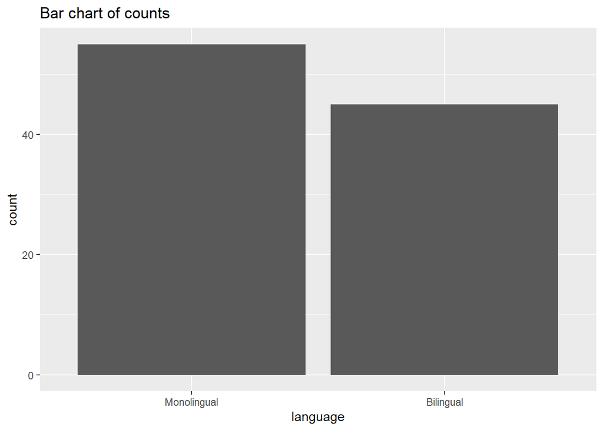

```r
ggplot(data = dat, mapping = aes(x = language)) +
  geom_bar() +
  labs(title="Bar chart of counts")
```

## 2.7 Aggregates and percentages

```r
dat_percent <- dat %>%
  group_by(language) %>%
  count() %>%
  ungroup() %>%
  mutate(percent = (n/sum(n)*100))
```

```r
dat_percent
```

| language | n | percent |
| --- | --- | --- |
| Monolingual | 55 | 55 |
| Bilingual | 45 | 45 |

Now omitting argument names

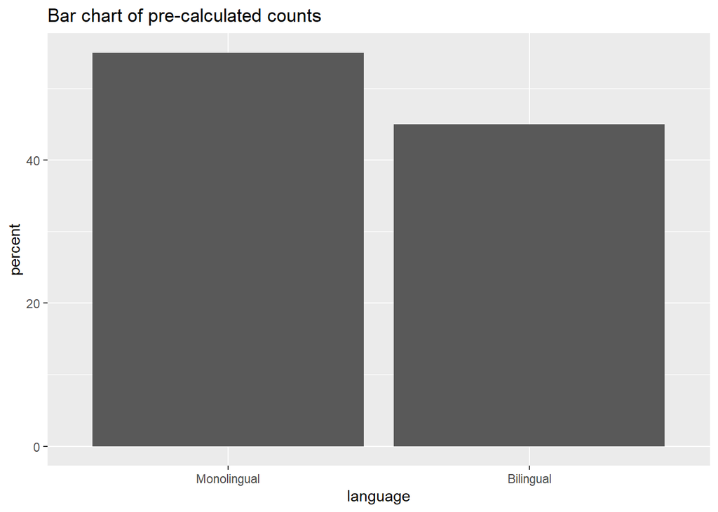

```r
ggplot(dat_percent, aes(x = language, y = percent)) +
  geom_bar(stat="identity") +
  labs(title="Bar chart of pre-calculated counts")
```

## 2.8 Histogram

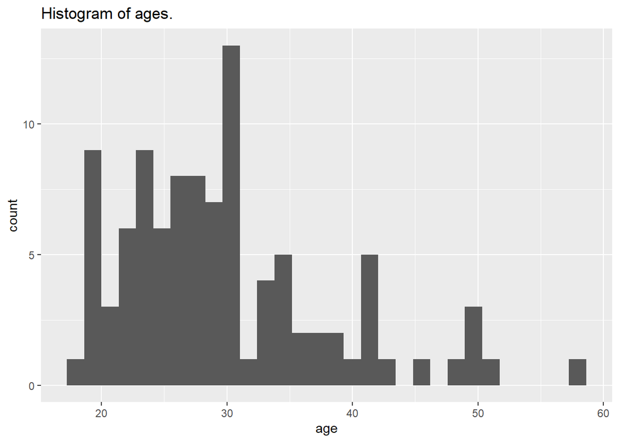

```r
ggplot(dat, aes(x = age)) +
  geom_histogram()+
  labs(title="Histogram of ages.")
```

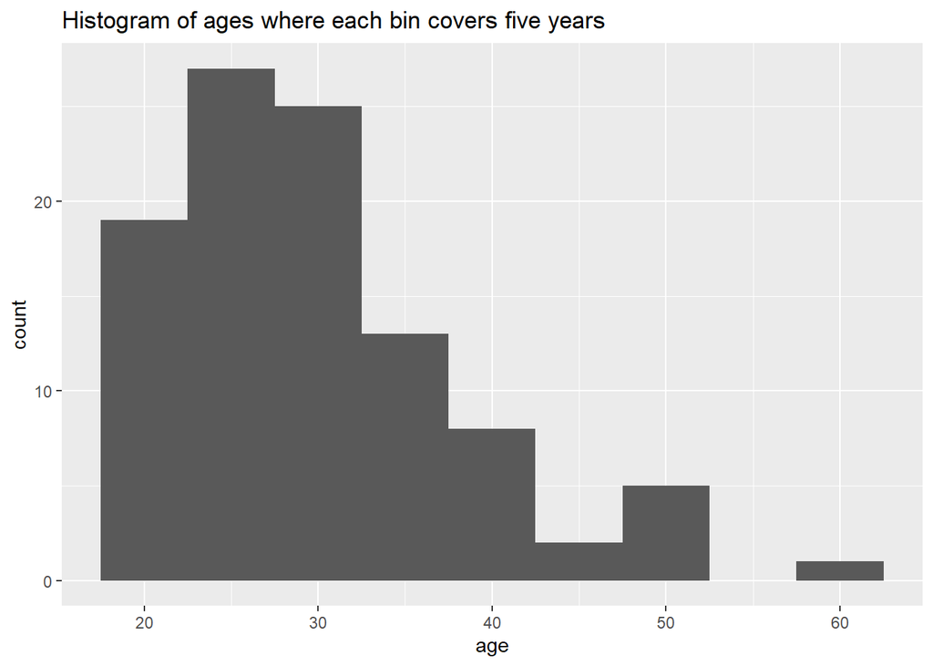

```r
ggplot(dat, aes(x = age)) +
  geom_histogram(binwidth = 5) +
  labs(title="Histogram of ages where each bin covers five years")
```

## 2.9 Customisation 1

### 2.9.1 Changing colours

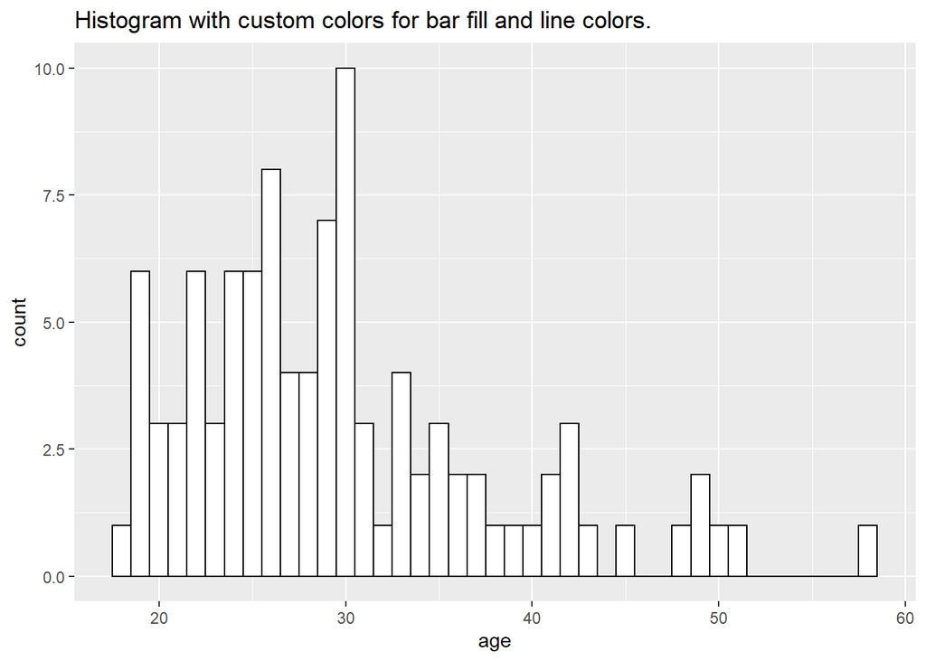

```r
ggplot(dat, aes(age)) +
  geom_histogram(binwidth = 1,
                 fill = "white",
                 colour = "black") +
  labs(title="Histogram with custom colors for bar fill and line colors.")
```

### 2.9.2 Editing axis names and labels

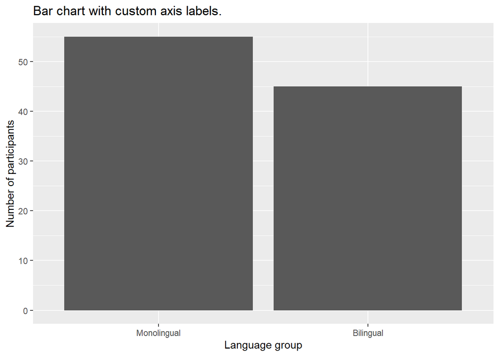

```r
ggplot(dat, aes(language)) +
  geom_bar() +
  scale_x_discrete(name = "Language group") +
  scale_y_continuous(name = "Number of participants",
                     breaks = c(0,10,20,30,40,50))+
  labs(title= "Bar chart with custom axis labels.")
```

- Discrete vs continuous errors

This code chunk throws an error if you actually run it: `Discrete value supplied to continuous scale`

```r
# produces an error
ggplot(dat, aes(language)) +
  geom_bar() +
  scale_x_continuous(name = "Language group")
```

```
Error: Discrete value supplied to continuous scale
```

### 2.9.3 Adding a theme

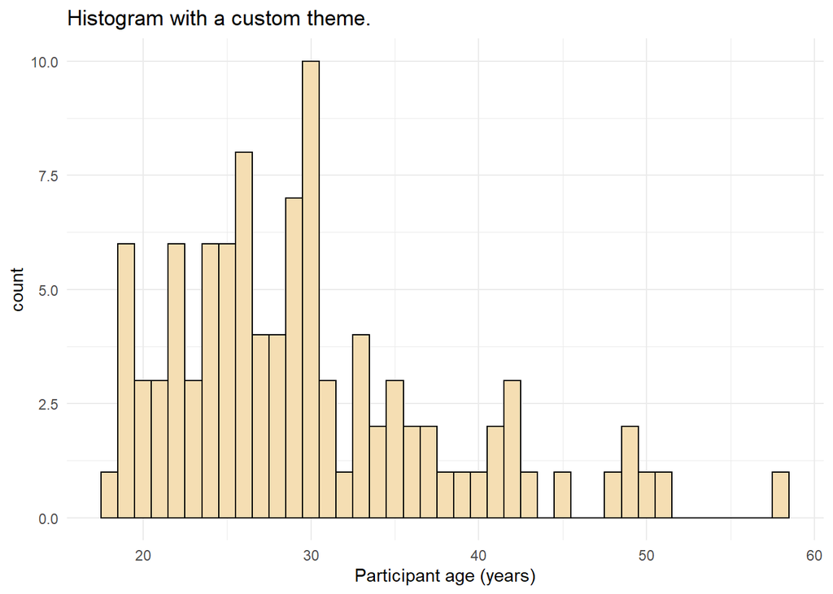

```r
ggplot(dat, aes(age)) +
  geom_histogram(binwidth = 1, fill = "wheat", color = "black") +
  scale_x_continuous(name = "Participant age (years)") +
  theme_minimal() +
  labs(title="Histogram with a custom theme.")
```

## 2.10 Activities 1

For the solutions, see [the website link](https://psyteachr.github.io/introdataviz/getting-started.html#activities-1)

1. Add a layer that edits the name of the y-axis histogram label to “Number of participants”

```r
# add code for 1 here
```

2. Change the colour of the bars in the bar chart to red.

```r
# add code for 2 here
```

3. Remove theme_minimal() from the histogram and instead apply one of the other available themes. To find out about other available themes, start typing theme_ and the auto-complete will show you the available options - this will only work if you have loaded the tidyverse library with library(tidyverse).

```r
# add code for 3 here
```

# 3 Chapter 3: Transforming Data

Note that Matt made some changes here from the published Glasgow tutorial, namely to explicitly set the condition variable that codes for word/nonword as a factor; and as a factor whose levels are explicitly declared. This has the consequence that later ggplot calls to `condition` don’t have to supply labels. Note that the published paper got the labels wrong for several plots. We avoid that possibility by setting the factor levels and labels in the data instead.

## 3.1 Data formats

Stuff about wide and long formats.

## 3.2 Wide to long format

### 3.2.1 Step 1: pivot_longer()

```r
long <- pivot_longer(data = dat,
                     cols = rt_word:acc_nonword,
                     names_to = c("dv_condition"),
                     values_to = "dv")
```

### 3.2.2 Step 2: pivot_longer()

```r
long2 <- pivot_longer(data = dat,
                     cols = rt_word:acc_nonword,
                     names_sep = "_",
                     names_to = c("dv_type", "condition"),
                     values_to = "dv")
```

### 3.2.3 Step 3: pivot_wider()

```r
dat_long <-
  pivot_wider(long2,
              names_from = "dv_type",
              values_from = "dv") %>%
  mutate(condition = factor(condition,
                            levels=c("word", "nonword"),
                            labels=c("Word", "Non-Word"))) %>%
  mutate(language = factor(language,
                           levels=c("monolingual", "bilingual"),
                           labels=c("Monolingual", "Bilingual")))
```

Combined steps

```r
dat_long <-
  pivot_longer(data = dat,
               cols = rt_word:acc_nonword,
               names_sep = "_",
               names_to = c("dv_type", "condition"),
               values_to = "dv") %>%
  pivot_wider(names_from = "dv_type",
              values_from = "dv") %>%
  mutate(condition = factor(condition,
                            levels=c("word", "nonword"),
                            labels=c("Word", "Non-Word")))%>%
  mutate(language = factor(language,
                           levels=c("monolingual", "bilingual"),
                           labels=c("Monolingual", "Bilingual")))
```

Load `dat_long.rda` for safety

```r
load("dat_long.rda")
```

## 3.3 Histogram 2

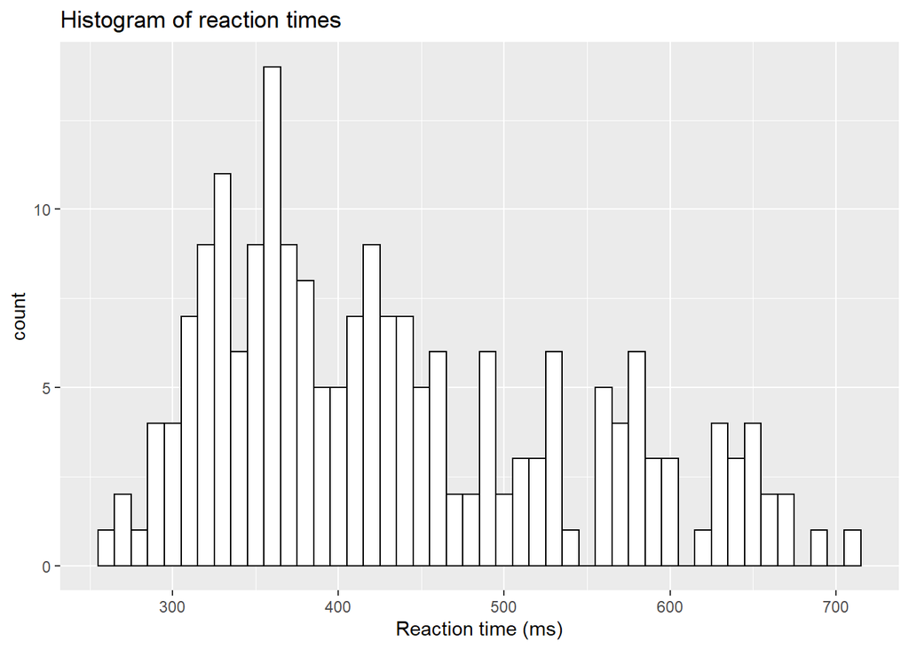

```r
ggplot(dat_long, aes(x = rt)) +
  geom_histogram(binwidth = 10, fill = "white", colour = "black") +
  scale_x_continuous(name = "Reaction time (ms)") +
  labs(title = "Histogram of reaction times")
```

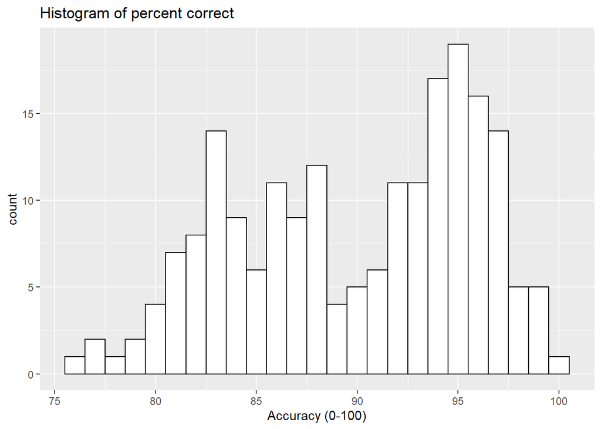

```r
ggplot(dat_long, aes(x = acc)) +
  geom_histogram(binwidth = 1, fill = "white", colour = "black") +
  scale_x_continuous(name = "Accuracy (0-100)") +
  labs(title = "Histogram of percent correct")
```

- Histogram with normal distribution

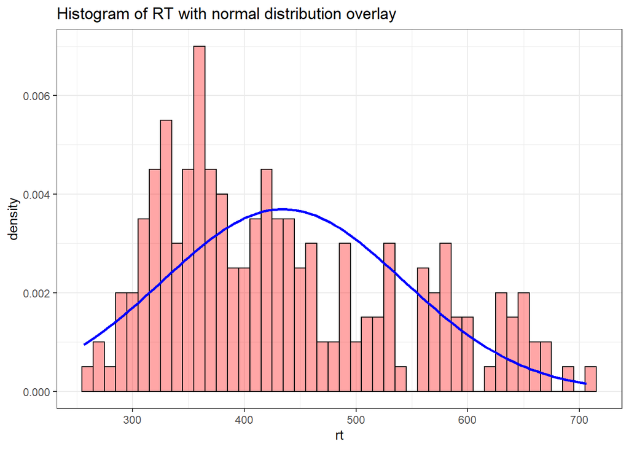

```r
ggplot(dat_long, aes(rt)) +
  geom_histogram(aes(y = ..density..),
                 binwidth = 10, fill = "red", color = "black", alpha=0.35) +
  stat_function(
    fun = dnorm,
    args = list(mean = mean(dat_long$rt),
                sd = sd(dat_long$rt)),
    lwd=1,
    color="blue"
  ) +
  labs(title = "Histogram of RT with normal distribution overlay")+
  theme_bw()
```

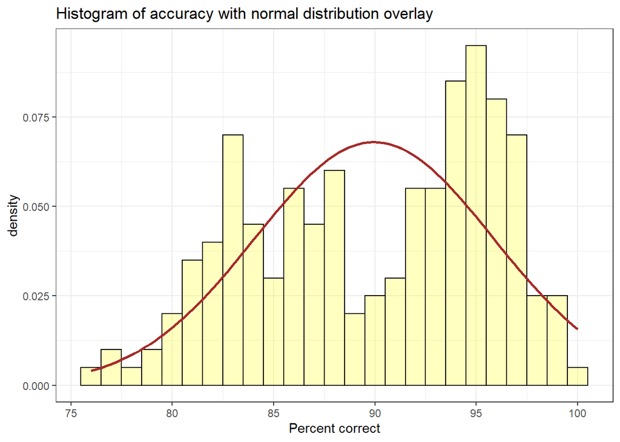

```r
ggplot(dat_long, aes(acc)) +
  geom_histogram(aes(y = ..density..),
                 binwidth = 1, fill = "yellow", color = "black", alpha=0.25) +
  stat_function(
    fun = dnorm,
    args = list(mean = mean(dat_long$acc),
                sd = sd(dat_long$acc)),
    lwd=1,
    color="brown"
  ) +
  labs(title = "Histogram of accuracy with normal distribution overlay") +
  xlab("Percent correct")+
  theme_bw()
```

## 3.4 Density plots

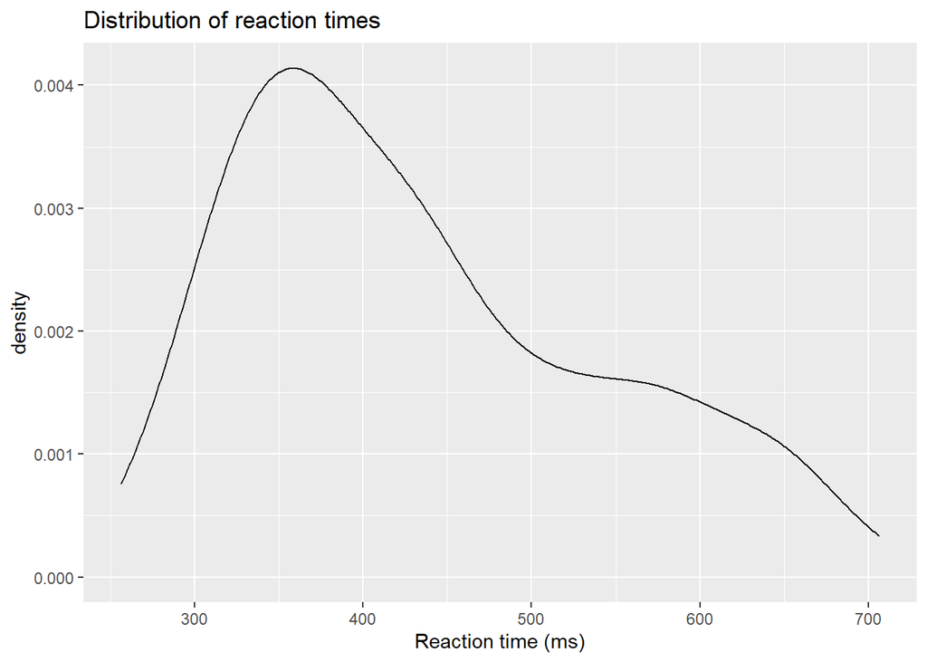

```r
ggplot(dat_long, aes(x = rt)) +
  geom_density()+
  scale_x_continuous(name = "Reaction time (ms)") +
  labs(title = "Distribution of reaction times")
```

### 3.4.1 Grouped density plots

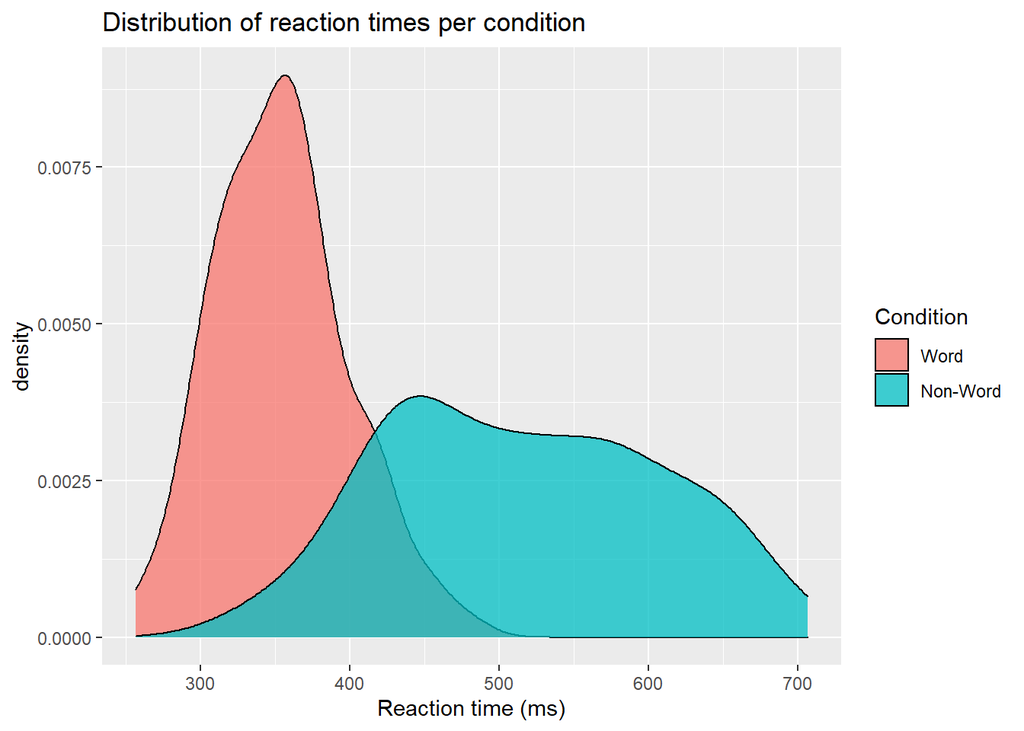

```r
ggplot(dat_long, aes(x = rt, fill = condition)) +
  geom_density(alpha = 0.75)+
  scale_x_continuous(name = "Reaction time (ms)")+
  scale_fill_discrete(name = "Condition")+
  labs(title = "Distribution of reaction times per condition")
```

## 3.5 Scatterplots

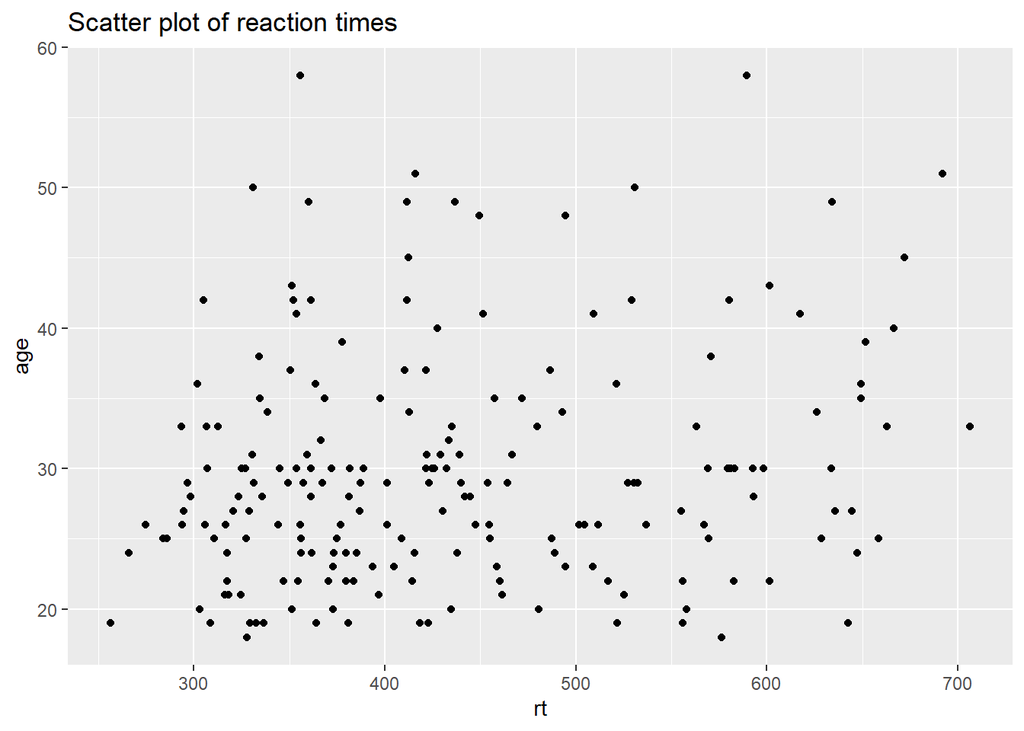

```r
ggplot(dat_long, aes(x = rt, y = age)) +
  geom_point() +
  labs(title = "Scatter plot of reaction times")
```

With line of best fit

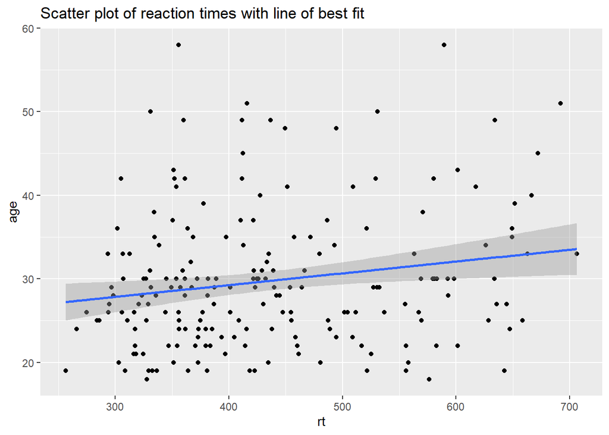

```r
ggplot(dat_long, aes(x = rt, y = age)) +
  geom_point() +
  geom_smooth(method = "lm") +
  labs(title = "Scatter plot of reaction times with line of best fit")
```

### 3.5.1 Grouped scatterplots

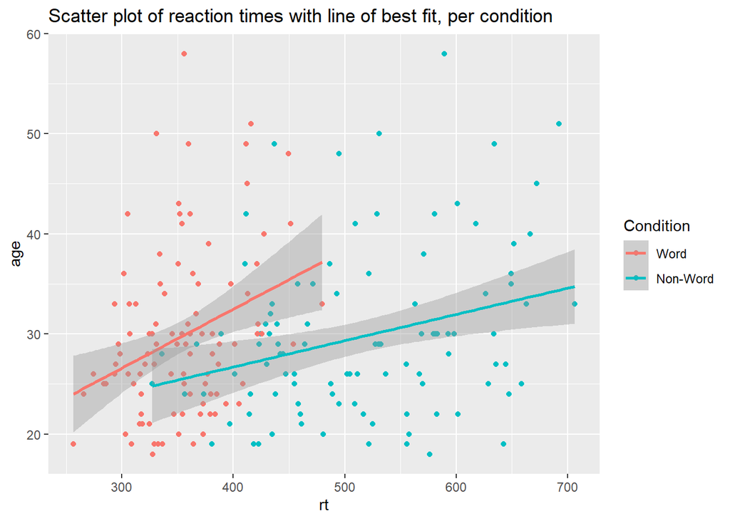

```r
ggplot(dat_long, aes(x = rt, y = age, colour = condition)) +
  geom_point() +
  geom_smooth(method = "lm") +
  scale_colour_discrete(name = "Condition") +
  labs(title = "Scatter plot of reaction times with line of best fit, per condition")
```

## 3.6 Long to wide format

Using the wide format from earlier

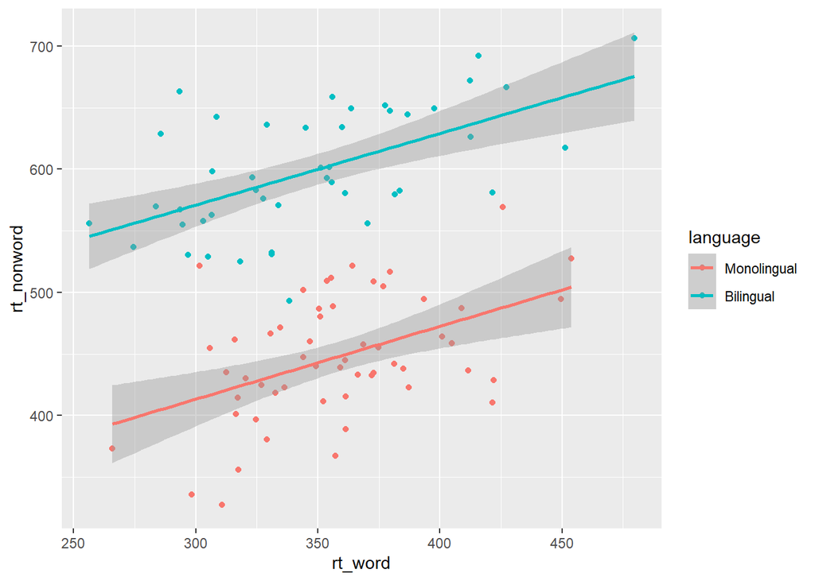

```r
ggplot(dat, aes(x = rt_word, y = rt_nonword, colour = language)) +
  geom_point() +
  geom_smooth(method = "lm")
```

Generating wide format from long format instead.

```r
dat_wide <- dat_long %>%
  pivot_wider(id_cols = "id",
              names_from = "condition",
              values_from = c(rt,acc))
```

## 3.7 Customisation 2

### 3.7.1 Accessible colour schemes

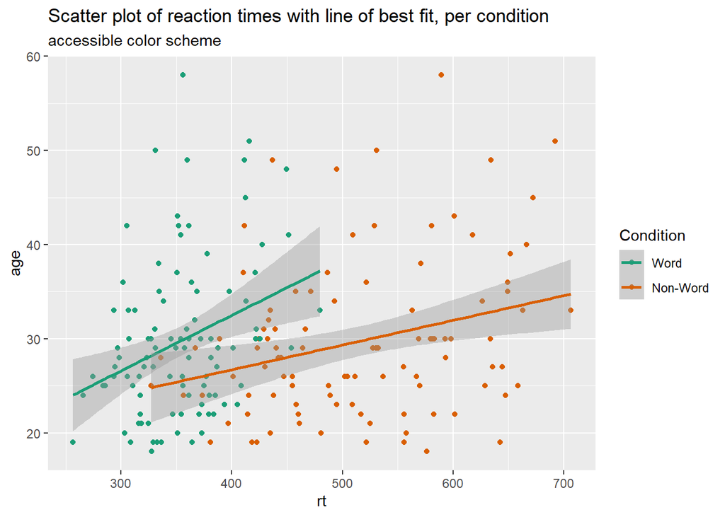

```r
ggplot(dat_long, aes(x = rt, y = age, colour = condition)) +
  geom_point() +
  geom_smooth(method = "lm") +
  scale_color_brewer(palette = "Dark2", name = "Condition") +
  labs(title = "Scatter plot of reaction times with line of best fit, per condition", subtitle="accessible color scheme")
```

### 3.7.2 Specifying axis breaks with `seq()`

The below code edits the y-axis so that age is displayed in increments of 5.

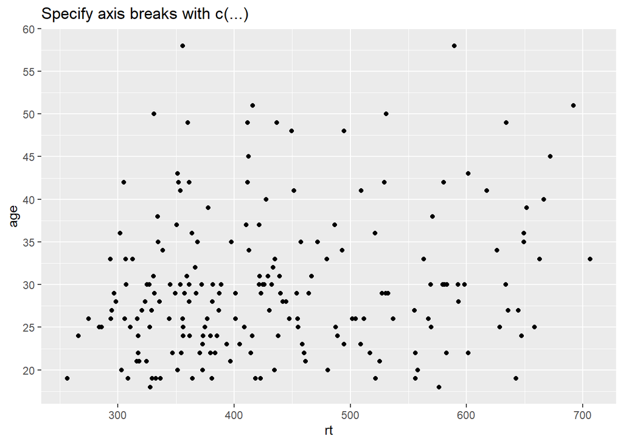

```r
ggplot(dat_long, aes(x = rt, y = age)) +
  geom_point() +
  scale_y_continuous(breaks = c(20,25,30,35,40,45,50,55,60)) +
  labs(title="Specify axis breaks with c(...)")
```

However, this is somewhat inefficient. Instead, we can use the function seq() (short for sequence) to specify the first and last value and the increments by which the breaks should display between these two values.

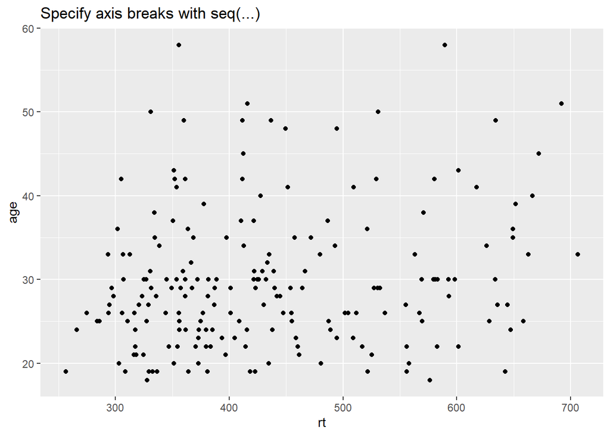

```r
ggplot(dat_long, aes(x = rt, y = age)) +
  geom_point() +
  scale_y_continuous(breaks = seq(20,60, by = 10)) +
  labs(title="Specify axis breaks with seq(...)")
```

## 3.8 Activities 2

For solutions see this [link to the website](https://psyteachr.github.io/introdataviz/transforming-data.html#activities-2)

1. Use fill to created grouped histograms that display the distributions for rt for each language group separately and also edit the fill axis labels. Try adding position = “dodge” to geom_histogram() to see what happens.

```r
# put answer to 1 here
```

2. Use scale_* functions to edit the name of the x and y-axis on the scatterplot

```r
# put answer to 2 here
```

3. Use se = FALSE to remove the confidence envelope from the scatterplots

```r
# put answer to 3 here
```

4. Remove method = “lm” from geom_smooth() to produce a curved fit line.

```r
# put answer to 4 here
```

5. Replace the default fill on the grouped density plot with a colour-blind friendly version.

```r
# put answer to 5 here
```

# 4 Chapter 4: Representing summary statistics

## 4.1 Boxplots

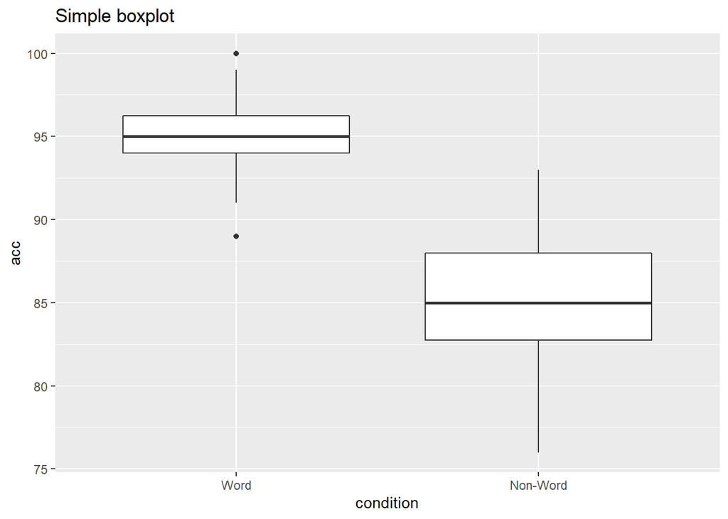

```r
ggplot(dat_long, aes(x = condition, y = acc)) +
  geom_boxplot() +
  labs(title="Simple boxplot")
```

### 4.1.1 Grouped boxplots

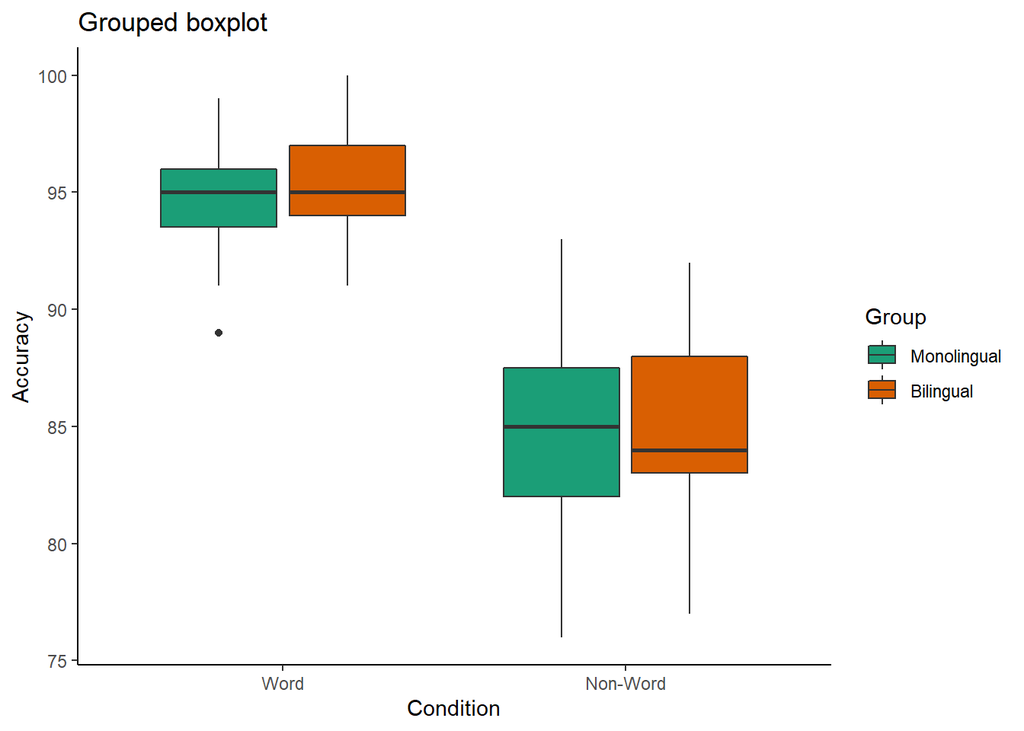

```r
ggplot(dat_long, aes(x = condition, y = acc, fill = language)) +
  geom_boxplot() +
  scale_fill_brewer(palette = "Dark2", name = "Group") +
  theme_classic() +
  scale_x_discrete(name = "Condition") +
  scale_y_continuous(name = "Accuracy") +
  labs(title = "Grouped boxplot")
```

## 4.2 Violin plots

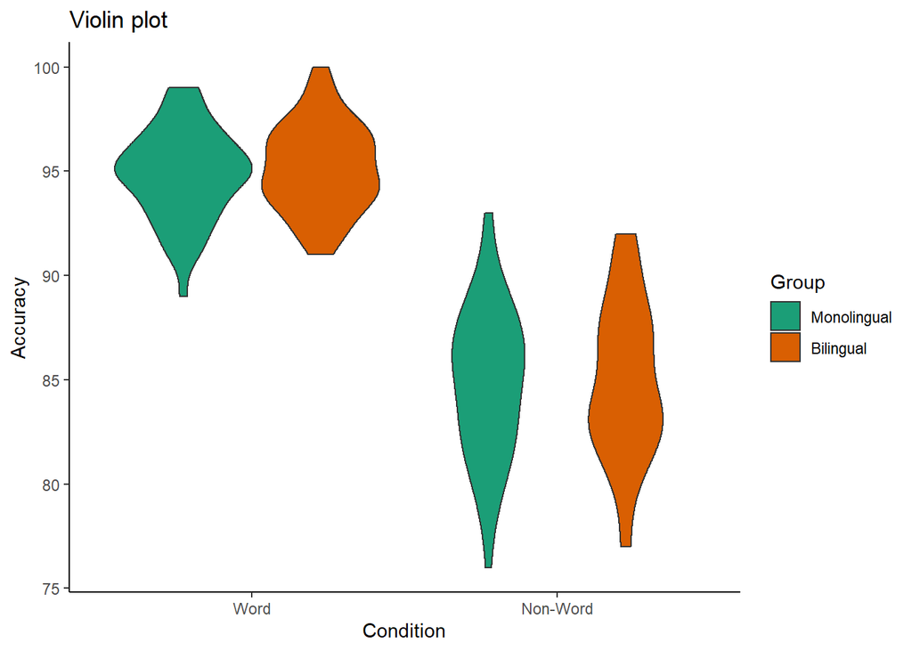

```r
ggplot(dat_long, aes(x = condition, y = acc, fill = language)) +
  geom_violin() +
  scale_fill_brewer(palette = "Dark2", name = "Group") +
  theme_classic() +
  scale_x_discrete(name = "Condition") +
  scale_y_continuous(name = "Accuracy") +
  labs(title = "Violin plot")
```

## 4.3 Bar chart of means

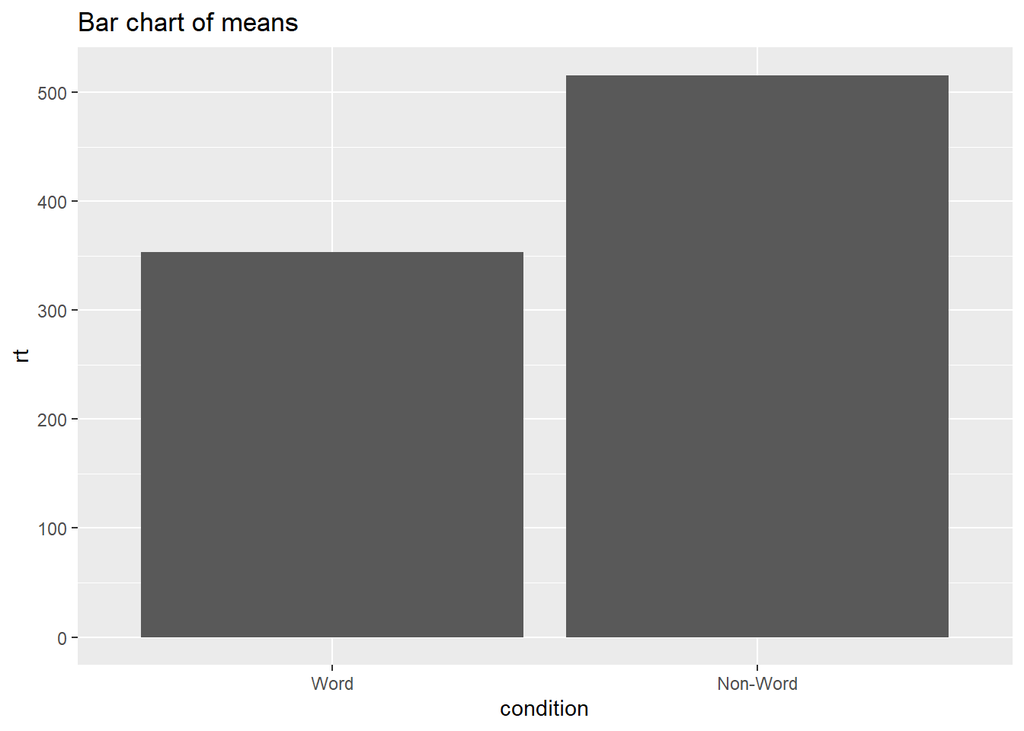

```r
ggplot(dat_long, aes(x = condition, y = rt)) +
  stat_summary(fun = "mean", geom = "bar") +
  labs(title = "Bar chart of means")
```

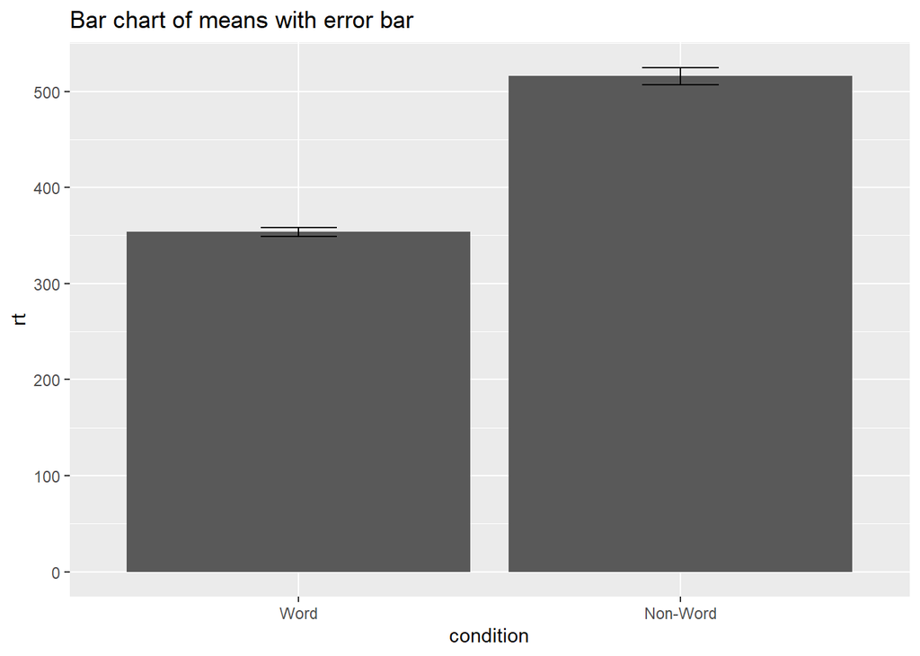

```r
ggplot(dat_long, aes(x = condition, y = rt)) +
  stat_summary(fun = "mean", geom = "bar") +
  stat_summary(fun.data = "mean_se", geom = "errorbar", width = .2) +
  labs(title = "Bar chart of means with error bar")
```

## 4.4 Violin-boxplot

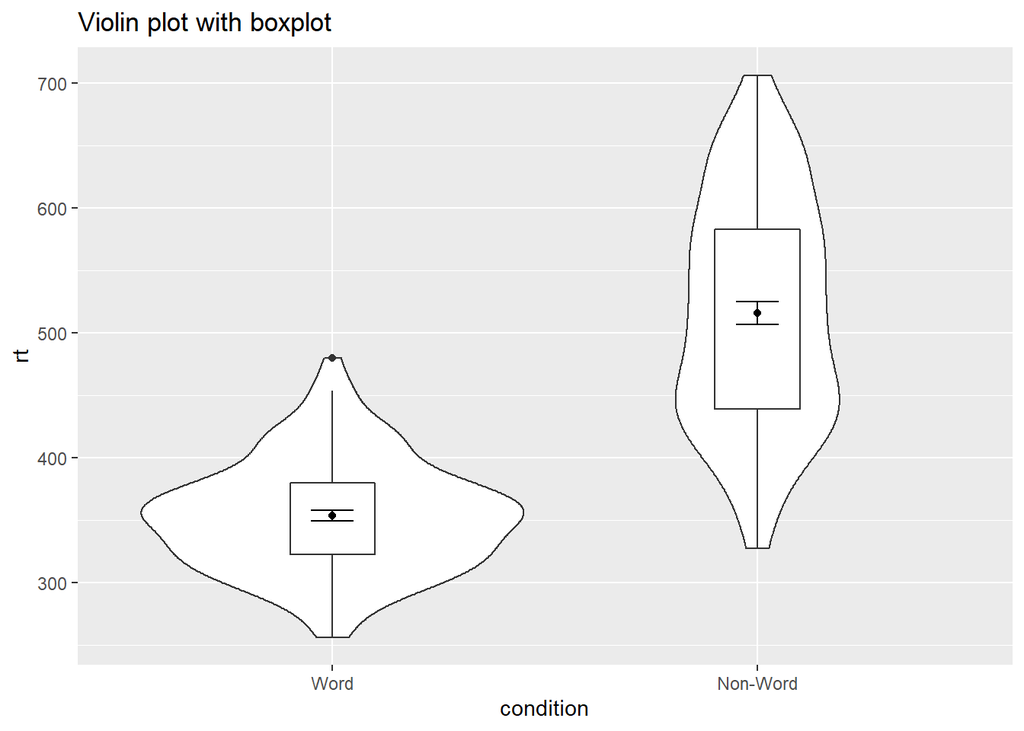

```r
ggplot(dat_long, aes(x = condition, y= rt)) +
  geom_violin() +
  # remove the median line with fatten = NULL
  geom_boxplot(width = .2, fatten = NULL) +
  stat_summary(fun = "mean", geom = "point") +
  stat_summary(fun.data = "mean_se", geom = "errorbar", width = .1) +
  labs(title = "Violin plot with boxplot")
```

Messy layers

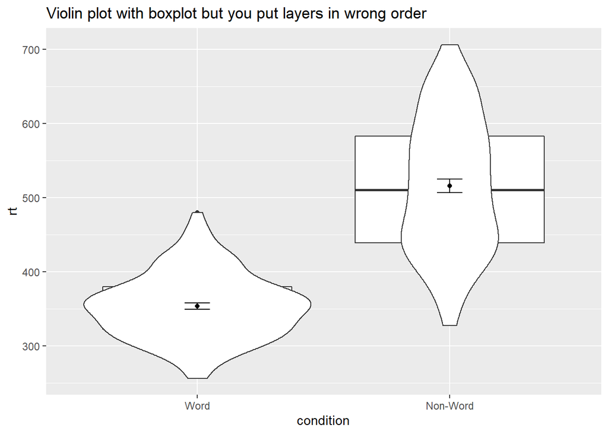

```r
ggplot(dat_long, aes(x = condition, y= rt)) +
  geom_boxplot() +
  geom_violin() +
  stat_summary(fun = "mean", geom = "point") +
  stat_summary(fun.data = "mean_se", geom = "errorbar", width = .1) +
  labs(title = "Violin plot with boxplot but you put layers in wrong order")
```

### 4.4.1 Grouped violin-boxplots

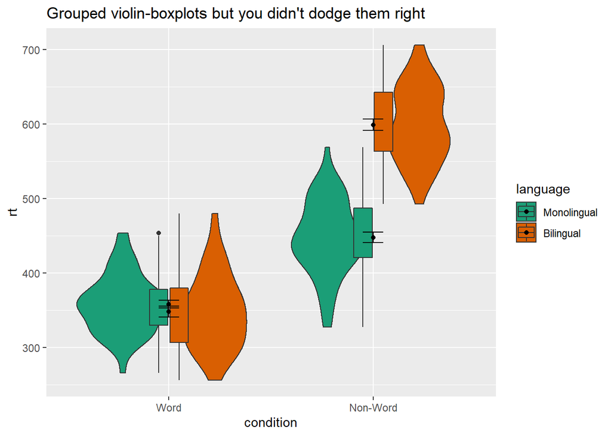

```r
ggplot(dat_long, aes(x = condition, y= rt, fill = language)) +
  geom_violin() +
  geom_boxplot(width = .2,
               fatten = NULL) +
  stat_summary(fun = "mean",  geom = "point") +
  stat_summary(fun.data = "mean_se",
               geom = "errorbar",
               width = .1) +
  scale_fill_brewer(palette = "Dark2") +
  labs(title = "Grouped violin-boxplots but you didn't dodge them right")
```

Fixed positions

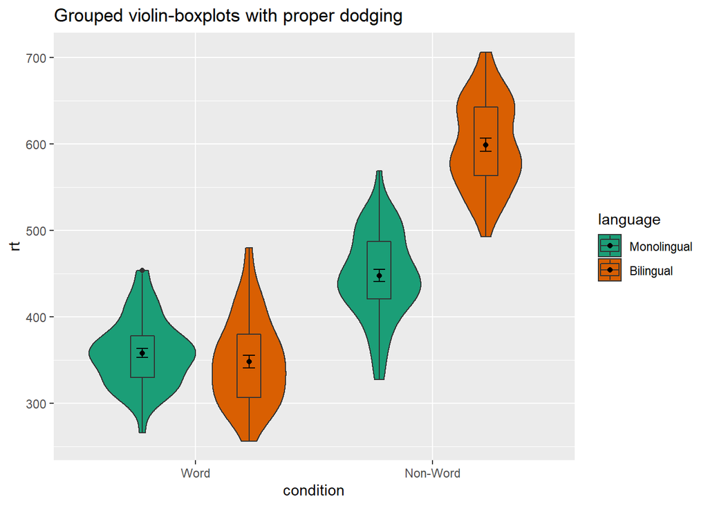

```r
# set the offset position of the geoms
pos <- position_dodge(0.9)

ggplot(dat_long, aes(x = condition, y= rt, fill = language)) +
  geom_violin(position = pos) +
  geom_boxplot(width = .2,
               fatten = NULL,
               position = pos) +
  stat_summary(fun = "mean",
               geom = "point",
               position = pos) +
  stat_summary(fun.data = "mean_se",
               geom = "errorbar",
               width = .1,
               position = pos) +
  scale_fill_brewer(palette = "Dark2") +
  labs(title = "Grouped violin-boxplots with proper dodging")
```

## 4.5 Customisation part 3

### 4.5.1 Colours

Hard to see colours

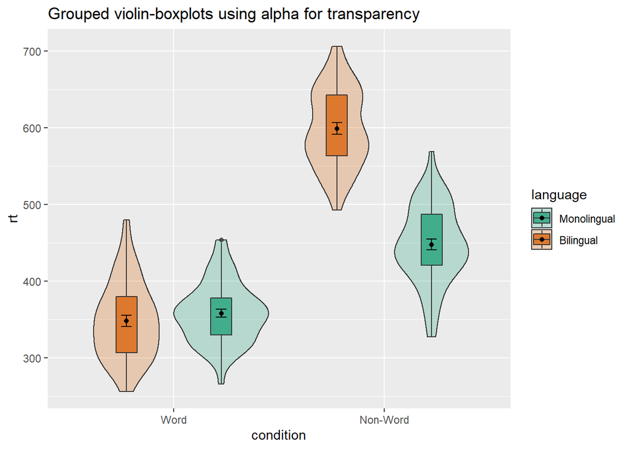

```r
ggplot(dat_long, aes(x = condition, y= rt, fill = language,
                     group = paste(condition, language))) +
  geom_violin(alpha = 0.25, position = pos) +
  geom_boxplot(width = .2,
               fatten = NULL,
               alpha = 0.75,
               position = pos) +
  stat_summary(fun = "mean",
               geom = "point",
               position = pos) +
  stat_summary(fun.data = "mean_se",
               geom = "errorbar",
               width = .1,
               position = pos) +
  scale_fill_brewer(palette = "Dark2") +
  labs(title = "Grouped violin-boxplots using alpha for transparency")
```

Adjusted geom colours

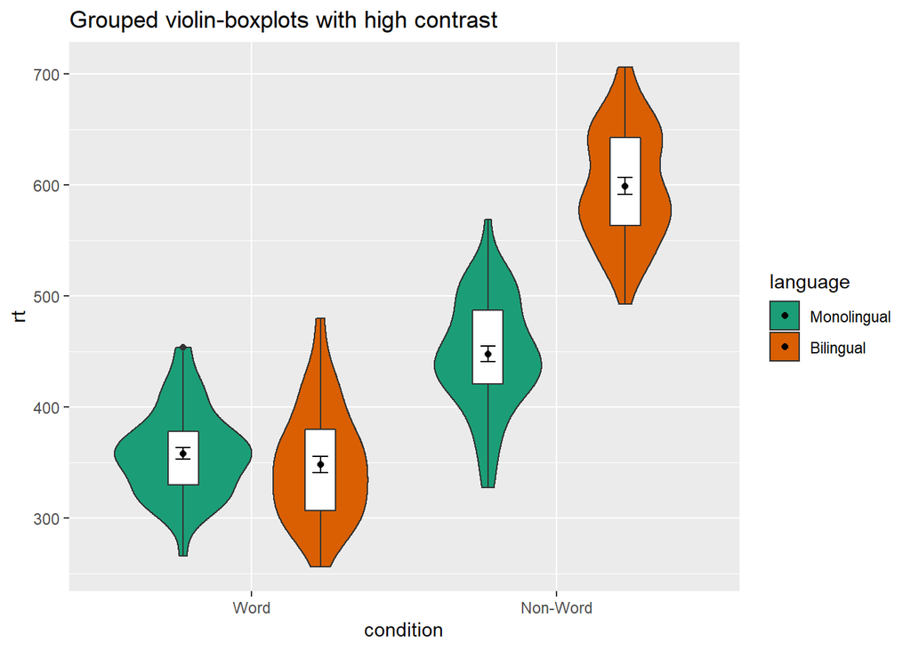

```r
ggplot(dat_long, aes(x = condition, y= rt, fill = language)) +
  geom_violin(position = pos) +
  geom_boxplot(width = .2, fatten = NULL,
               mapping = aes(group = interaction(condition, language)),
               fill = "white",
               position = pos) +
  stat_summary(fun = "mean",
               geom = "point",
               position = pos) +
  stat_summary(fun.data = "mean_se",
               geom = "errorbar",
               width = .1,
               position = pos) +
  scale_fill_brewer(palette = "Dark2") +
  labs(title = "Grouped violin-boxplots with high contrast")
```

## 4.6 Activities 3

For solutions see [this link to the website](https://psyteachr.github.io/introdataviz/representing-summary-statistics.html#activities-3)

1. Review all the code you have run so far. Try to identify the commonalities between each plot’s code and the bits of the code you might change if you were using a different dataset.
2. Take a moment to recognise the complexity of the code you are now able to read.
3. For the violin-boxplot, for geom = “point”, try changing fun to median

```r
# put answer to 3 here
```

4. For the violin-boxplot, for geom = “errorbar”, try changing fun.data to mean_cl_normal (for 95% CI)

```r
# put answer to 4 here
```

5. Go back to the grouped density plots and try changing the transparency with alpha.

```r
# put answer to 5 here
```